# Eighth Week: Text Analysis in R

To be, or not to be

Seyederfan Hosseini _ 93101373

2018-05-04 17:35:44

> با استفاده از بسته gutenberg داده های لازم را به دست آورید و به سوالات زیر پاسخ دهید.

```r
path = "~/R/HW8/hw_08/images"
library(tidytext)
library(dplyr)
library(stringr)
library(wordcloud)
library(gutenbergr)
library(highcharter)
library(tokenizers)
library(ggplot2)
```

۱. چارلز دیکنز نویسنده معروف انگلیسی بالغ بر چهارده رمان (چهارده و نیم) نوشته است. متن تمامی کتاب های او را دانلود کنید و سپس بیست لغت برتر استفاده شده را به صورت یک نمودار ستونی نمایش دهید. (طبیعتا باید ابتدا متن را پاکسازی کرده و stopping words را حذف نمایید تا به کلماتی که بار معنایی مشخصی منتقل می کنند برسید.)

```r
listOfCodes = c(580, 730, 967, 700, 917, 968, 821, 766, 1023, 786, 963, 98, 1400, 883, 564)
listOfBooks = c("The Pickwick Papers", "Oliver Twist", "Nicholas Nickleby", "The Old Curiosity Shop",
                "Barnaby Rudge", "Martin Chuzzlewit", "Dombey and Son", "David Copperfield",
                "Bleak House", "Hard Times", "Little Dorrit", "A Tale of Two Cities",
                "Great Expectations", "Our Mutual Friend", "The Mystery of Edwin Drood")
books = list()
listWord = list()
for(i in 1:length(listOfCodes)){
    books[[i]] = gutenberg_download(listOfCodes[i])
    }
for(i in 1:length(listOfCodes)){
    dick = books[[i]]
    dick %>% str_replace_all("\"", "") -> dick
    dick %>% str_replace_all("[[:punct:]]","") %>% str_split(pattern = "\\s") %>% unlist() %>% table() %>% as.data.frame(stringsAsFactors = F) -> dick
    colnames(dick) = c("word","count")
    dick %>%
        filter(!str_to_lower(word) %in% stop_words$word) %>%
        filter(str_length(word)>1) %>%
        filter(!str_detect(word,"\\d")) %>%
        arrange(desc(count)) -> dick
    dick %>% mutate(proper = !word %in% str_to_lower(word)) -> dick
    listWord[[i]] = dick
}

stat = bind_rows(listWord)
stat %>% mutate(word = str_to_lower(word)) %>% filter(word != "dont") %>%  group_by(word) %>% summarise(count = sum(count)) %>% arrange(desc(count)) -> stat
top20 = stat %>% head(20)
hchart(top20, hcaes(x = word, y=count), type = 'bar') %>%
    hc_yAxis(title = list(text = 'Number of occurance')) %>%
    hc_xAxis(title = list(text = 'Word'))
```

[interactive chart not shown]

۲. ابر لغات ۲۰۰ کلمه پرتکرار در رمان های چارلز دیکنز را رسم نمایید. این کار را با بسته wordcloud2 انجام دهید. برای دانلود می توانید به لینک زیر مراجعه کنید.

https://github.com/Lchiffon/wordcloud2

با استفاده از عکسی که در ابتدا متن آمده ابر لغاتی مانند شکل زیر رسم کنید. (راهنمایی: از ورودی figpath در دستور wordcloud2 استفاده نمایید.مثالی در زیر آورده شده است.)

[figure not shown]

```r
top200 = stat %>% head(200)
library(wordcloud2)
# wordcloud2(top200, color='skyblue', figPath = paste(path, 'pox.png', sep = '/' ), size=0.7)
```

۳. اسم پنج شخصیت اصلی در هر رمان دیکنز را استخراج کنید و با نموداری تعداد دفعات تکرار شده بر حسب رمان را رسم نمایید. (مانند مثال کلاس در رسم اسامی شخصیت ها در سری هر پاتر)

```r
listName = data.frame()
for(i in 1:length(listOfCodes)){
    tmp = listWord[[i]]
    tmp = tmp %>% filter(proper & !str_to_lower(word) %in% word) %>% head(5) %>% select(name = word, count)
    tmp = tmp %>% mutate(rate = count/sum(count)*100) %>% select(name, rate) %>% mutate(book = listOfBooks[i])
    listName = bind_rows(listName, tmp)
}
hchart(listName, type='column', hcaes(x = book, y=rate, group=name))
```

[interactive chart not shown]

۴. در بسته tidytext داده ایی به نام sentiments وجود دارد که فضای احساسی لغات را مشخص می نماید. با استفاده از این داده نمودار ۲۰ لغت برتر negative و ۲۰ لغت برتر positive را در کنار هم رسم نمایید. با استفاده از این نمودار فضای حاکم بر داستان چگونه ارزیابی می کنید؟ (به طور مثال برای کتاب داستان دو شهر فضای احساسی داستان به ترتیب تکرر در نمودار زیر قابل مشاهده است.)

```r
story = listWord[[5]]
story %>% mutate(word = str_to_lower(word)) %>% group_by(word) %>% summarise(count = sum(count)) -> story
story %>% filter(word %in% sentiments$word) %>% full_join(sentiments %>% select(word, sentiment)) %>% na.omit() -> state
```

```r
state %>% filter(sentiment == "positive" | sentiment == "negative") %>% unique(by='word') -> state
state %>% group_by(sentiment) %>% arrange(desc(count)) %>% slice(1:20) -> stateTops
hchart(stateTops, type = 'column', hcaes(x = sentiment, y = count, group = word))
```

[interactive chart not shown]

We will use a hypothesis test to determine stronger sentiment

```r
t.test(state$count[which(state$sentiment=="negative")], state$count[which(state$sentiment=="positive")], alternative = 'less')
```

```
##
##  Welch Two Sample t-test
##
## data:  state$count[which(state$sentiment == "negative")] and state$count[which(state$sentiment == "positive")]
## t = -3.7964, df = 2881.3, p-value = 7.492e-05
## alternative hypothesis: true difference in means is less than 0
## 95 percent confidence interval:
##       -Inf -1.263233
## sample estimates:
## mean of x mean of y
##  6.182498  8.412015
```

We can conclude that positive words are used more frequently.

۵. متن داستان بینوایان را به ۲۰۰ قسمت مساوی تقسیم کنید. برای هر قسمت تعداد لغات positive و negative را حساب کنید و سپس این دو سری زمانی را در کنار هم برای مشاهده فضای احساسی داستان رسم نمایید.

Below occurance percentage of positive and negative words is plotted against the section number.

```r
mis = gutenberg_download(135)
mis %>% mutate(section = ceiling(row_number() / 337) ) -> mis
rep = data.frame()
for(i in 1:200){
    crt = mis %>% filter(section == i)
    crt %>% str_replace_all("\"", "") %>% str_replace_all("[[:punct:]]","") %>% str_split(pattern = "\\s") %>% unlist() %>% table() %>% as.data.frame(stringsAsFactors = F) -> crt
    colnames(crt) = c("word","count")
    crt %>% mutate(word = str_to_lower(word)) %>% group_by(word) %>% summarise(count = sum(count)) -> crt
    crt %>% filter(word %in% sentiments$word) %>% full_join(sentiments %>% select(word, sentiment)) %>% na.omit() %>%
        filter(sentiment == "positive" | sentiment == "negative") %>% unique(by='word') %>%
        group_by(sentiment) %>% summarise(count = sum(count)) -> crt
    rep = bind_rows(rep, crt %>% mutate(section = i))
}
rep %>% group_by(section) %>% mutate(rate = count / sum(count)*100) -> rep

hchart(rep, type = 'line', hcaes(x = section, y=rate, group=sentiment))
```

[interactive chart not shown]

۶. ابتدا ترکیبات دوتایی کلماتی که پشت سر هم می آیند را استخراج کنید و سپس نمودار ۳۰ جفت لغت پرتکرار را رسم نمایید.

```r
crt = books[[3]]
pairs = crt$text %>% tokenize_ngrams(n=2, lowercase = T) %>% unlist() %>% table() %>% data.frame(stringsAsFactors = F)
colnames(pairs) = c("pair", "count")
pairs %>% arrange(desc(count)) %>% head(30) -> topPair
hchart(topPair, type = 'bar', hcaes(x = pair, y=count)) %>%
    hc_xAxis(title = list(text = '2-gram')) %>%
    hc_yAxis(title = list(text = 'Number of occurance'))
```

[interactive chart not shown]

۷. جفت کلماتی که با she و یا he آغاز می شوند را استخراج کنید. بیست فعل پرتکراری که زنان و مردان در داستان های دیکنز انجام می دهند را استخراج کنید و نمودار آن را رسم نمایید.

Pairs starting with “he” or “she” are extracted below and 20 tops are plotted.

```r
she = str_match_all(crt %>% str_to_lower(), "she \\w+")[[2]] %>% table %>% data.frame(stringsAsFactors = F)
colnames(she) = c("pair", "count")
she = she %>% arrange(desc(count))
hchart(she %>% head(20), type='bar', hcaes(x=pair, y = count)) %>%
    hc_yAxis(title = list(text = 'Number of occurance')) %>%
    hc_xAxis(title = list(text = 'Pair'))
```

[interactive chart not shown]

```r
he1 = str_match_all(crt, " he \\w+")[[2]] %>% table %>% data.frame(stringsAsFactors = F)
he2 = str_match_all(crt, "He \\w+")[[2]] %>% table %>% data.frame(stringsAsFactors = F)
colnames(he1) = c("pair", "count")
colnames(he2) = c("pair", "count")
he = list()
he[[1]] = he1
he[[2]] = he2
he = bind_rows(he) %>% mutate(pair = str_to_lower(pair)) %>% group_by(pair) %>% summarise(count = sum(count))
he = he %>% arrange(desc(count))
hchart(he %>% head(20), type='bar', hcaes(x=pair, y = count)) %>%
    hc_yAxis(title = list(text = 'Number of occurance')) %>%
    hc_xAxis(title = list(text = 'Pair'))
```

[interactive chart not shown]

Verbs of pairs are detected and summed over gender and top 20 is plotted below:

```r
he$verb = 'NA'
for(i in 1:length(he$verb)){
    pair = he$pair[i]
    verb = unlist(str_split(pair, " "))[3]
    he$verb[i] = verb
}
she$verb = 'NA'
for(i in 1:length(she$verb)){
    pair = she$pair[i]
    verb = unlist(str_split(pair, " "))[2]
    she$verb[i] = verb
}
rep = bind_rows(he, she) %>% na.omit() %>% group_by(verb) %>% summarise(count = sum(count)) %>% arrange(desc(count))
hchart(rep, type = 'bar', hcaes(x = verb, y = count))
```

[interactive chart not shown]

۸. برای کتاب های دیکنز ابتدا هر فصل را جدا کنید. سپی برای هر فصل 1-gram, 2-gram را استخراج کنید. آیا توزیع N-gram در کارهای دیکنز یکسان است؟ با رسم نمودار هم این موضوع را بررسی کنید.

In the code below, a chapter column is added to the data frame, text of book “Oliver Twist”, then for each chapter, 1-gram and 2-gram is extracted and distribution of 1-gram and 2-gram for different chapters are plotted.

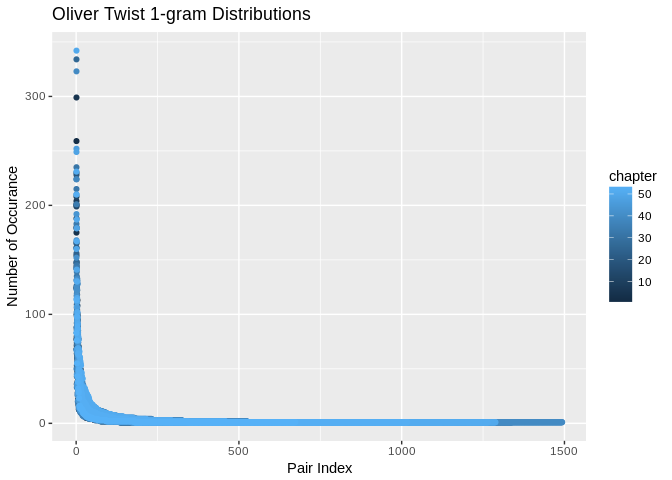

```r
crt = books[[2]]
crt$chapter = 0
for(i in 1:nrow(crt)){
    row = crt[i,2]
    if(str_detect(row, "^CHAPTER")){
        crt$chapter[i] = 1
    }
}
crt$chapter = cumsum(crt$chapter)
gram1Chap = data.frame()
gram2Chap = data.frame()
for(i in 1:max(crt$chapter)){
    tmp = crt %>% filter(chapter == i)
    gram1 = tokenize_ngrams(tmp$text, n=1, lowercase = T) %>%
        unlist() %>% table() %>% data.frame(stringsAsFactors = F)
    colnames(gram1) = c("pair", "count")
    gram1 = gram1 %>% arrange(desc(count)) %>% mutate(idx = row_number()) %>% mutate(chapter = i)
    gram1Chap = bind_rows(gram1Chap, gram1)
    gram2 = tokenize_ngrams(tmp$text, n=2, lowercase = T) %>%
        unlist() %>% table() %>% data.frame(stringsAsFactors = F)
    colnames(gram2) = c("pair", "count")
    gram2 = gram2 %>% arrange(desc(count)) %>% mutate(idx = row_number()) %>% mutate(chapter = i)
    gram2Chap = bind_rows(gram2Chap, gram2)
}
ggplot(data = gram1Chap, aes(x = idx, y=count, color = chapter)) +
    geom_point() +
    ggtitle("Oliver Twist 1-gram Distributions") +
    xlab("Pair Index") +
    ylab("Number of Occurance")
```

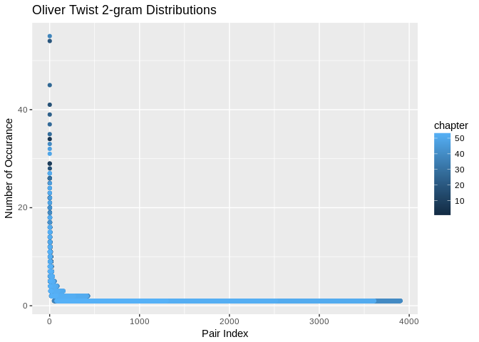

```r
ggplot(data = gram2Chap, aes(x = idx, y=count, color = chapter)) +
    geom_point() +
    ggtitle("Oliver Twist 2-gram Distributions") +
    xlab("Pair Index") +
    ylab("Number of Occurance")
```

We can conclude from plots that distribution of 1-grams and 2-grams remain same through out the stroy. In the code below, 1-grams and 2-grams are extracted for each book and then parameters of a fitted distribution are determined and saved to a matrix.

```r
gram1Co = c()
gram2Co = c()
for (i in 1:15){
    crt = books[[i]]
    gram1 = tokenize_ngrams(crt$text, n=1, lowercase = T) %>%
        unlist() %>% table() %>% data.frame(stringsAsFactors = F)
    colnames(gram1) = c("pair", "count")
    gram1 = gram1 %>% arrange(desc(count)) %>% mutate(idx = row_number())
    lm = lm(log(count)~log(idx), data = gram1)
    coef1gram = lm$coefficients
    gram2 = tokenize_ngrams(crt$text, n=2, lowercase = T) %>%
        unlist() %>% table() %>% data.frame(stringsAsFactors = F)
    colnames(gram2) = c("pair", "count")
    gram2 = gram2 %>% arrange(desc(count)) %>% mutate(idx = row_number())
    lm = lm(log(count)~log(idx), data = gram2)
    coef2gram = lm$coefficients
    gram1Co = cbind(gram1Co, coef1gram)
    gram2Co = cbind(gram2Co, coef2gram)
}
gram1Co = data.frame(gram1Co)
colnames(gram1Co) = listOfBooks
gram2Co = data.frame(gram2Co)
colnames(gram2Co) = listOfBooks
```

Parameters for 1-gram distributions:

```r
print(gram1Co)
```

```
##             The Pickwick Papers Oliver Twist Nicholas Nickleby
## (Intercept)           12.495451    11.356530         12.599806
## log(idx)              -1.311644    -1.249842         -1.324784
##             The Old Curiosity Shop Barnaby Rudge Martin Chuzzlewit
## (Intercept)              11.857948     12.207681         12.543126
## log(idx)                 -1.279737     -1.302981         -1.317108
##             Dombey and Son David Copperfield Bleak House Hard Times
## (Intercept)      12.760560         12.801378   12.685953  10.215548
## log(idx)         -1.339845         -1.356801   -1.335682  -1.155217
##             Little Dorrit A Tale of Two Cities Great Expectations
## (Intercept)     12.577561            10.909011          11.401371
## log(idx)        -1.324912            -1.211812          -1.252359
##             Our Mutual Friend The Mystery of Edwin Drood
## (Intercept)          12.43902                   9.946210
## log(idx)             -1.30904                  -1.118856
```

Parameters for 2-gram distributions:

```r
print(gram2Co)
```

```
##             The Pickwick Papers Oliver Twist Nicholas Nickleby
## (Intercept)           7.1559829    6.3094050         7.3175438
## log(idx)             -0.6403625   -0.5925129        -0.6514219
##             The Old Curiosity Shop Barnaby Rudge Martin Chuzzlewit
## (Intercept)              6.7118465     6.9178573         7.3590194
## log(idx)                -0.6150001    -0.6257062        -0.6538639
##             Dombey and Son David Copperfield Bleak House Hard Times
## (Intercept)       7.492183         7.8129528    7.568051  5.7361916
## log(idx)         -0.663782        -0.6963716   -0.672262 -0.5579437
##             Little Dorrit A Tale of Two Cities Great Expectations
## (Intercept)     7.4298704             6.082519          6.8237455
## log(idx)       -0.6610224            -0.578630         -0.6377274
##             Our Mutual Friend The Mystery of Edwin Drood
## (Intercept)         7.3522572                  5.3827401
## log(idx)           -0.6555498                 -0.5252623
```

We can see that except for books “Hard Times” and “The Mystry of Edwin Drood” distribution for N-grams are the same.

۹. برای آثار ارنست همینگوی نیز تمرین ۸ را تکرار کنید. آیا بین آثار توزیع n-grams در بین آثار این دو نویسنده یکسان است؟

Enrest Hemingway novels are not available in gutenberg package so books “Anna Karenina”, “War and Peace”, “The Cossacks”, “Ressurection” from Leon Tolstoy are going to be analysed.

```r
tolstBooks = list()
code =c(1399, 2600, 4761, 1938)
bookNames = c("Anna Karenina", "War and Peace", "The Cossacks", "Resurrection")
for(i in 1:length(code)){
    tolstBooks[[i]] = gutenberg_download(code[i])
}
gram1Co = c()
gram2Co = c()
for (i in 1:length(code)){
    crt = tolstBooks[[i]]
    gram1 = tokenize_ngrams(crt$text, n=1, lowercase = T) %>%
        unlist() %>% table() %>% data.frame(stringsAsFactors = F)
    colnames(gram1) = c("pair", "count")
    gram1 = gram1 %>% arrange(desc(count)) %>% mutate(idx = row_number())
    lm = lm(log(count)~log(idx), data = gram1)
    coef1gram = lm$coefficients
    gram2 = tokenize_ngrams(crt$text, n=2, lowercase = T) %>%
        unlist() %>% table() %>% data.frame(stringsAsFactors = F)
    colnames(gram2) = c("pair", "count")
    gram2 = gram2 %>% arrange(desc(count)) %>% mutate(idx = row_number())
    lm = lm(log(count)~log(idx), data = gram2)
    coef2gram = lm$coefficients
    gram1Co = cbind(gram1Co, coef1gram)
    gram2Co = cbind(gram2Co, coef2gram)
}
gram1Co = data.frame(gram1Co)
colnames(gram1Co) = bookNames
gram2Co = data.frame(gram2Co)
colnames(gram2Co) = bookNames
print(gram1Co)
```

```
##             Anna Karenina War and Peace The Cossacks Resurrection
## (Intercept)     13.125887     14.023778    10.118646    11.790229
## log(idx)        -1.398168     -1.439784    -1.200464    -1.304112
```

```r
print(gram2Co)
```

```
##             Anna Karenina War and Peace The Cossacks Resurrection
## (Intercept)     7.9068362      8.308020     5.280049    6.8977977
## log(idx)       -0.7058757     -0.713258    -0.536619   -0.6476486
```

As we can see, distribution for Tolstoy’s works are almost the same like Dickens works.